# EE658/758 Machine Learning in Engineering

## Assignment-3: Neural Network

### 1. Data Preprocessing:

**• Load the dataset and perform initial exploratory data analysis.**

**• Handle null values appropriately (e.g., using imputation or removal).**

**• Convert categorical variables to a suitable numerical format.**

**• Encode the target variable 'Segmentation' for the classification task.**

```python
import os

import numpy as np
import pandas as pd
import seaborn as sns

# np.random.seed(1)


import matplotlib.pyplot as plt

from sklearn.neural_network import MLPClassifier
from sklearn.model_selection import train_test_split, cross_val_score
from sklearn.preprocessing import StandardScaler
from sklearn.metrics import accuracy_score, f1_score, classification_report, confusion_matrix
from sklearn.linear_model import LogisticRegression
from sklearn.model_selection import KFold, learning_curve
from sklearn.model_selection import learning_curve
```

```python
df_train = pd.read_csv('train.csv')
df_test = pd.read_csv('test.csv')

df_train.head()
```

|  | ID | Gender | Ever_Married | Age | Graduated | Profession | Work_Experience | Spending_Score | Family_Size | Var_1 | Segmentation |
| --- | --- | --- | --- | --- | --- | --- | --- | --- | --- | --- | --- |
| 0 | 462809 | Male | No | 22 | No | Healthcare | 1.0 | Low | 4.0 | Cat_4 | D |
| 1 | 462643 | Female | Yes | 38 | Yes | Engineer | NaN | Average | 3.0 | Cat_4 | A |
| 2 | 466315 | Female | Yes | 67 | Yes | Engineer | 1.0 | Low | 1.0 | Cat_6 | B |
| 3 | 461735 | Male | Yes | 67 | Yes | Lawyer | 0.0 | High | 2.0 | Cat_6 | B |
| 4 | 462669 | Female | Yes | 40 | Yes | Entertainment | NaN | High | 6.0 | Cat_6 | A |

```python
df_train.info()
```

```
<class 'pandas.core.frame.DataFrame'>
RangeIndex: 8068 entries, 0 to 8067
Data columns (total 11 columns):
 #   Column           Non-Null Count  Dtype
---  ------           --------------  -----
 0   ID               8068 non-null   int64
 1   Gender           8068 non-null   object
 2   Ever_Married     7928 non-null   object
 3   Age              8068 non-null   int64
 4   Graduated        7990 non-null   object
 5   Profession       7944 non-null   object
 6   Work_Experience  7239 non-null   float64
 7   Spending_Score   8068 non-null   object
 8   Family_Size      7733 non-null   float64
 9   Var_1            7992 non-null   object
 10  Segmentation     8068 non-null   object
dtypes: float64(2), int64(2), object(7)
memory usage: 693.5+ KB
```

```python
df_train.describe()
```

|  | ID | Age | Work_Experience | Family_Size |
| --- | --- | --- | --- | --- |
| count | 8068.000000 | 8068.000000 | 7239.000000 | 7733.000000 |
| mean | 463479.214551 | 43.466906 | 2.641663 | 2.850123 |
| std | 2595.381232 | 16.711696 | 3.406763 | 1.531413 |
| min | 458982.000000 | 18.000000 | 0.000000 | 1.000000 |
| 25% | 461240.750000 | 30.000000 | 0.000000 | 2.000000 |
| 50% | 463472.500000 | 40.000000 | 1.000000 | 3.000000 |
| 75% | 465744.250000 | 53.000000 | 4.000000 | 4.000000 |
| max | 467974.000000 | 89.000000 | 14.000000 | 9.000000 |

```python
for col in df_train.columns[1:]:
    print(f"{col} column has {df_train[col].isnull().sum()} null values")
```

```
Gender column has 0 null values
Ever_Married column has 140 null values
Age column has 0 null values
Graduated column has 78 null values
Profession column has 124 null values
Work_Experience column has 829 null values
Spending_Score column has 0 null values
Family_Size column has 335 null values
Var_1 column has 76 null values
Segmentation column has 0 null values
```

```python
for col in df_test.columns[1:]:
    print(f"{col} column has {df_test[col].isnull().sum()} null values")
```

```
Gender column has 0 null values
Ever_Married column has 50 null values
Age column has 0 null values
Graduated column has 24 null values
Profession column has 38 null values
Work_Experience column has 269 null values
Spending_Score column has 0 null values
Family_Size column has 113 null values
Var_1 column has 32 null values
```

```python
# Fill missing values in numerical columns with mean
df_train['Work_Experience'].fillna(df_train['Work_Experience'].mean(), inplace=True)
df_test['Work_Experience'].fillna(df_test['Work_Experience'].mean(), inplace=True)

df_train['Family_Size'].fillna(df_train['Family_Size'].mean(), inplace=True)
df_test['Family_Size'].fillna(df_test['Family_Size'].mean(), inplace=True)

# Fill missing values in object columns with mode
df_train['Ever_Married'].fillna(df_train['Ever_Married'].mode()[0], inplace=True)
df_test['Ever_Married'].fillna(df_test['Ever_Married'].mode()[0], inplace=True)

df_train['Graduated'].fillna(df_train['Graduated'].mode()[0], inplace=True)
df_test['Graduated'].fillna(df_test['Graduated'].mode()[0], inplace=True)

df_train['Profession'].fillna(df_train['Profession'].mode()[0], inplace=True)
df_test['Profession'].fillna(df_test['Profession'].mode()[0], inplace=True)

df_train['Var_1'].fillna(df_train['Var_1'].mode()[0], inplace=True)
df_test['Var_1'].fillna(df_test['Var_1'].mode()[0], inplace=True)
```

```python
for col in df_train.columns[1:]:
    print(f"{col} column has {df_train[col].isnull().sum()} null values")
```

```
Gender column has 0 null values
Ever_Married column has 0 null values
Age column has 0 null values
Graduated column has 0 null values
Profession column has 0 null values
Work_Experience column has 0 null values
Spending_Score column has 0 null values
Family_Size column has 0 null values
Var_1 column has 0 null values
Segmentation column has 0 null values
```

```python
for col in df_test.columns[1:]:
    print(f"{col} column has {df_test[col].isnull().sum()} null values")
```

```
Gender column has 0 null values
Ever_Married column has 0 null values
Age column has 0 null values
Graduated column has 0 null values
Profession column has 0 null values
Work_Experience column has 0 null values
Spending_Score column has 0 null values
Family_Size column has 0 null values
Var_1 column has 0 null values
```

```python
df_train = pd.get_dummies(df_train, columns=['Ever_Married', 'Graduated', 'Profession', 'Var_1', 'Gender'], drop_first=True)
df_test = pd.get_dummies(df_test, columns=['Ever_Married', 'Graduated', 'Profession', 'Var_1', 'Gender'], drop_first=True)
```

```python
# Label Encoding for Spending_Score column (assuming it's ordinal)
spending_score_mapping = {'Low': 0, 'Average': 1, 'High': 2}
df_train['Spending_Score'] = df_train['Spending_Score'].map(spending_score_mapping)
df_test['Spending_Score'] = df_test['Spending_Score'].map(spending_score_mapping)

segmentation_mapping = {'A': 0, 'B': 1, 'C': 2, 'D': 3}
df_train['Segmentation'] = df_train['Segmentation'].map(segmentation_mapping)
```

```python
df_train.head()
```

|  | ID | Age | Work_Experience | Spending_Score | Family_Size | Segmentation | Ever_Married_Yes | Graduated_Yes | Profession_Doctor | Profession_Engineer | ... | Profession_Homemaker | Profession_Lawyer | Profession_Marketing | Var_1_Cat_2 | Var_1_Cat_3 | Var_1_Cat_4 | Var_1_Cat_5 | Var_1_Cat_6 | Var_1_Cat_7 | Gender_Male |
| --- | --- | --- | --- | --- | --- | --- | --- | --- | --- | --- | --- | --- | --- | --- | --- | --- | --- | --- | --- | --- | --- |
| 0 | 462809 | 22 | 1.000000 | 0 | 4.0 | 3 | 0 | 0 | 0 | 0 | ... | 0 | 0 | 0 | 0 | 0 | 1 | 0 | 0 | 0 | 1 |
| 1 | 462643 | 38 | 2.641663 | 1 | 3.0 | 0 | 1 | 1 | 0 | 1 | ... | 0 | 0 | 0 | 0 | 0 | 1 | 0 | 0 | 0 | 0 |
| 2 | 466315 | 67 | 1.000000 | 0 | 1.0 | 1 | 1 | 1 | 0 | 1 | ... | 0 | 0 | 0 | 0 | 0 | 0 | 0 | 1 | 0 | 0 |
| 3 | 461735 | 67 | 0.000000 | 2 | 2.0 | 1 | 1 | 1 | 0 | 0 | ... | 0 | 1 | 0 | 0 | 0 | 0 | 0 | 1 | 0 | 1 |
| 4 | 462669 | 40 | 2.641663 | 2 | 6.0 | 0 | 1 | 1 | 0 | 0 | ... | 0 | 0 | 0 | 0 | 0 | 0 | 0 | 1 | 0 | 0 |

5 rows × 23 columns

```python
df_train['Work_Experience'] = df_train['Work_Experience'].astype(int)
df_test['Work_Experience'] = df_test['Work_Experience'].astype(int)
```

```python
X = df_train.drop(columns=['Segmentation', 'ID'])
Y = df_train['Segmentation']

X_test = df_test.drop(columns=['ID'])

scaler = StandardScaler()

X[['Age', 'Work_Experience', 'Family_Size']] = scaler.fit_transform(X[['Age', 'Work_Experience', 'Family_Size']])
X_test[['Age', 'Work_Experience', 'Family_Size']] = scaler.transform(X_test[['Age', 'Work_Experience', 'Family_Size']])

X = X.values
Y = Y.values

X_test = X_test.values


X_train, X_val, y_train, y_val = train_test_split(X, Y, test_size=0.2, random_state=42)
```

### 2. Neural Network Implementation from Scratch:

**• Implement a two-layer neural network model from scratch focusing on understanding the underlying mathematics and operations (e.g., forward propagation, backpropagation).**

**• Apply the model to the preprocessed dataset.**

```python
def forward(X, W1, b1, W2, b2):
    Z = 1 / (1 + np.exp(-X.dot(W1) - b1))
    A = Z.dot(W2) + b2
    expA = np.exp(A)
    Y = expA / expA.sum(axis=1, keepdims=True)
    return Y, Z


# determine the classification rate
# num correct / num total
def classification_rate(Y, P):
    n_correct = 0
    n_total = 0
    for i in range(len(Y)):
        n_total += 1
        if Y[i] == P[i]:
            n_correct += 1
    return float(n_correct) / n_total


def derivative_w2(Z, T, Y):
    N, K = T.shape
    M = Z.shape[1] # H is (N, M)

    ret4 = Z.T.dot(T - Y)

    return ret4


def derivative_w1(X, Z, T, Y, W2):
    N, D = X.shape
    M, K = W2.shape

    dZ = (T - Y).dot(W2.T) * Z * (1 - Z)
    ret2 = X.T.dot(dZ)

    # assert(np.abs(ret1 - ret2).sum() < 0.00001)

    return ret2


def derivative_b2(T, Y):
    return (T - Y).sum(axis=0)


def derivative_b1(T, Y, W2, Z):
    return ((T - Y).dot(W2.T) * Z * (1 - Z)).sum(axis=0)


def cost(T, Y):
    tot = T * np.log(Y)
    return tot.sum()


def train(X, Y):
    # create the data
    D = X.shape[1] # dimensionality of input
    M = 10 # hidden layer size
    K = len(set(Y)) # number of classes


    N = len(Y)
    # turn Y into an indicator matrix for training
    T = np.zeros((N, K))
    for i in range(N):
        T[i, Y[i]] = 1



    # randomly initialize weights
    W1 = np.random.randn(D, M)
    b1 = np.random.randn(M)
    W2 = np.random.randn(M, K)
    b2 = np.random.randn(K)

    learning_rate = 1e-3
    costs = []
    for epoch in range(10000):
        output, hidden = forward(X, W1, b1, W2, b2)
        if epoch % 100 == 0:
            c = cost(T, output)
            P = np.argmax(output, axis=1)
            r = classification_rate(Y, P)
            print("cost:", c, "classification_rate:", r)
            costs.append(c)

        # this is gradient ASCENT, not DESCENT
        # be comfortable with both!
        # oldW2 = W2.copy()

        gW2 = derivative_w2(hidden, T, output)
        gb2 = derivative_b2(T, output)
        gW1 = derivative_w1(X, hidden, T, output, W2)
        gb1 = derivative_b1(T, output, W2, hidden)

        W2 += learning_rate * gW2
        b2 += learning_rate * gb2
        W1 += learning_rate * gW1
        b1 += learning_rate * gb1

    return W1, b1, W2, b2


def predict(X, W1, b1, W2, b2):
    Y, _ = forward(X, W1, b1, W2, b2)
    predictions = np.argmax(Y, axis=1)
    return predictions


W1, b1, W2, b2 = train(X_train, y_train)

pred = predict(X_val, W1, b1, W2, b2)


print("Accuracy Score: ", accuracy_score(y_val, pred))
print(confusion_matrix(y_val, pred))

print(classification_report(y_val, pred))
```

```
cost: -18547.756934908804 classification_rate: 0.27331887201735355
cost: -7758.061659215124 classification_rate: 0.4301208552835451
cost: -7417.953554730604 classification_rate: 0.4426712116516889
cost: -7232.99974584602 classification_rate: 0.4801673380849086
cost: -7128.341145130727 classification_rate: 0.4973659745894019
cost: -7064.39446116763 classification_rate: 0.5063526495196777
cost: -7128.825173873535 classification_rate: 0.4910133250697242
cost: -7032.924717703385 classification_rate: 0.5057328788348311
cost: -6998.133854078956 classification_rate: 0.5111558723272389
cost: -6967.389530173581 classification_rate: 0.5131701270529904
cost: -6939.280881828055 classification_rate: 0.5171986365044934
cost: -6912.705151723817 classification_rate: 0.5218469166408429
cost: -6888.406666433335 classification_rate: 0.5221568019832662
cost: -6867.606066470845 classification_rate: 0.5226216299969011
cost: -6850.142354186481 classification_rate: 0.5237062286953827
cost: -6835.072281332065 classification_rate: 0.5252556554074992
cost: -6821.590270845601 classification_rate: 0.5266501394484041
cost: -6809.159060660162 classification_rate: 0.5257204834211342
cost: -6797.48748002156 classification_rate: 0.5264951967771925
cost: -6786.497192574447 classification_rate: 0.5281995661605207
cost: -6776.224985999481 classification_rate: 0.5300588782150605
cost: -6766.69368265006 classification_rate: 0.5316083049271769
cost: -6757.825189684555 classification_rate: 0.5325379609544468
cost: -6749.465398043443 classification_rate: 0.5340873876665634
cost: -6741.509914149912 classification_rate: 0.5351719863650449
cost: -6733.951827799257 classification_rate: 0.5348621010226217
cost: -6726.787082552471 classification_rate: 0.5350170436938333
cost: -6719.821393663136 classification_rate: 0.5359466997211032
cost: -6712.417868733499 classification_rate: 0.5368763557483731
cost: -6704.36464565504 classification_rate: 0.5356368143786799
cost: -6698.0957722504945 classification_rate: 0.5359466997211032
cost: -6693.386527172852 classification_rate: 0.5356368143786799
cost: -6688.6495943152595 classification_rate: 0.5359466997211032
cost: -6683.653284369434 classification_rate: 0.5354818717074682
cost: -6678.670352992373 classification_rate: 0.5362565850635265
cost: -6674.018631220352 classification_rate: 0.5371862410907964
cost: -6669.886593939499 classification_rate: 0.5368763557483731
cost: -6666.312613361992 classification_rate: 0.5365664704059498
cost: -6663.232129582024 classification_rate: 0.537341183762008
cost: -6660.538295674027 classification_rate: 0.5364115277347381
```

[output cut: 60 more lines]

```
Accuracy Score:  0.516728624535316
[[139 118  29 105]
 [ 71 172  82  44]
 [ 29 115 181  55]
 [ 76  47   9 342]]
              precision    recall  f1-score   support

           0       0.44      0.36      0.39       391
           1       0.38      0.47      0.42       369
           2       0.60      0.48      0.53       380
           3       0.63      0.72      0.67       474

    accuracy                           0.52      1614
   macro avg       0.51      0.50      0.50      1614
weighted avg       0.52      0.52      0.51      1614
```

### 3. Neural Network using Scikit-learn:

**• Use MLPClassifier class of the scikit-learn library to implement a neural network model with 2 layers.**

**• Train the model on the preprocessed dataset.**

**• Repeat with three layers.**

**• Investigate how the accuracy of the two-layer neural network model varies with the number of neurons in each hidden layer.**

**• Plot a graph with the number of neurons on the X-axis and the corresponding accuracy on the Y-axis.**

**• Provide a brief analysis of how the number of neurons in the hidden layers affects the model's performance. Consider discussing any trends, optimal neuron counts, and possible reasons for the observed performance changes.**

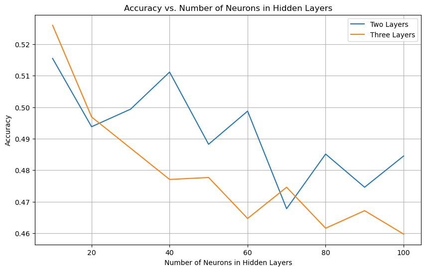

```python
neuron_counts = [10, 20, 30, 40, 50, 60, 70, 80, 90, 100]

accuracy_2_layers = []
accuracy_3_layers = []

# Train models for each neuron count
for hidden_layer_size in neuron_counts:
    # Train two-layer neural network
    mlp_2_layers = MLPClassifier(hidden_layer_sizes=(hidden_layer_size, hidden_layer_size), max_iter=1000, random_state=42)
    mlp_2_layers.fit(X_train, y_train)
    accuracy_2_layers.append(accuracy_score(y_val, mlp_2_layers.predict(X_val)))

    # Train three-layer neural network
    mlp_3_layers = MLPClassifier(hidden_layer_sizes=(hidden_layer_size, hidden_layer_size, hidden_layer_size), max_iter=1000, random_state=42)
    mlp_3_layers.fit(X_train, y_train)
    accuracy_3_layers.append(accuracy_score(y_val, mlp_3_layers.predict(X_val)))

# Plotting the results
plt.figure(figsize=(10, 6))
plt.plot(neuron_counts, accuracy_2_layers, label='Two Layers')
plt.plot(neuron_counts, accuracy_3_layers, label='Three Layers')
plt.xlabel('Number of Neurons in Hidden Layers')
plt.ylabel('Accuracy')
plt.title('Accuracy vs. Number of Neurons in Hidden Layers')
plt.legend()
plt.grid(True)
plt.show()
```

**Hidden Layers and Network Performance :**

**Identifying the sweet spot—the optimal neuron count—rests on several factors. Data complexity plays a pivotal role; intricate datasets may necessitate a higher neuron count to unravel their mysteries. The size of the training set also influences this balance; larger datasets enable effective handling of more parameters, potentially pushing the optimal neuron count higher. Moreover, network architecture matters; deeper networks often require fewer neurons per layer compared to shallower ones to grasp complex patterns.**

**Determining the ideal neuron count entails a blend of art and science, involving experimentation with various configurations. Techniques like validation sets prove invaluable in detecting overfitting and steering the model towards optimal performance.**

**In essence, this exploration underscores the quest for equilibrium. Too few neurons lead to underfitting, overlooking critical patterns, while an excess triggers overfitting, excelling on training data but floundering on unseen examples. The objective is to craft a network robust enough to learn without losing sight of generalization principles.**

```python
mlp_2_layers = MLPClassifier(hidden_layer_sizes=(100, 100), max_iter=1000, random_state=42)

mlp_2_layers.fit(X_train, y_train)

pred = mlp_2_layers.predict(X_val)


print("Accuracy Score for 2 layer: ", accuracy_score(y_val, pred))
print(confusion_matrix(y_val, pred))

print(classification_report(y_val, pred))




mlp_3_layers = MLPClassifier(hidden_layer_sizes=(100, 100, 100), max_iter=1000, random_state=42)

mlp_3_layers.fit(X_train, y_train)

pred = mlp_3_layers.predict(X_val)


print("Accuracy Score for 3 layer: ", accuracy_score(y_val, pred))
print(confusion_matrix(y_val, pred))

print(classification_report(y_val, pred))
```

```
Accuracy Score for 2 layer:  0.48451053283767037
[[143  79  86  83]
 [ 84 111 125  49]
 [ 43  73 220  44]
 [ 97  35  34 308]]
              precision    recall  f1-score   support

           0       0.39      0.37      0.38       391
           1       0.37      0.30      0.33       369
           2       0.47      0.58      0.52       380
           3       0.64      0.65      0.64       474

    accuracy                           0.48      1614
   macro avg       0.47      0.47      0.47      1614
weighted avg       0.48      0.48      0.48      1614

Accuracy Score for 3 layer:  0.459727385377943
[[149  77  65 100]
 [103  85 123  58]
 [ 61  68 210  41]
 [ 98  43  35 298]]
              precision    recall  f1-score   support

           0       0.36      0.38      0.37       391
           1       0.31      0.23      0.26       369
           2       0.48      0.55      0.52       380
           3       0.60      0.63      0.61       474

    accuracy                           0.46      1614
   macro avg       0.44      0.45      0.44      1614
weighted avg       0.45      0.46      0.45      1614
```

### 4. Logistic Regression Implementation:

**• Implement a logistic regression model using scikit-learn as a baseline for comparison.**

**• Train the model on the same preprocessed dataset.**

```
Accuracy Score:  0.4993804213135068
[[185  44  87  75]
 [113  55 163  38]
 [ 67  24 241  48]
 [100  13  36 325]]
              precision    recall  f1-score   support

           0       0.40      0.47      0.43       391
           1       0.40      0.15      0.22       369
           2       0.46      0.63      0.53       380
           3       0.67      0.69      0.68       474

    accuracy                           0.50      1614
   macro avg       0.48      0.49      0.46      1614
weighted avg       0.49      0.50      0.48      1614
```

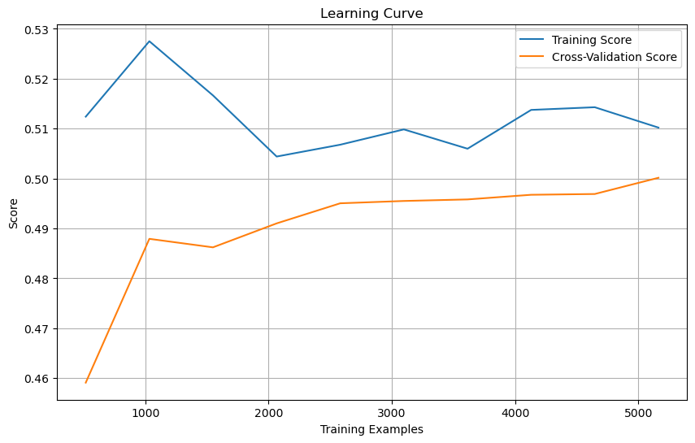

```python
classifier = LogisticRegression()

# Initialize k-fold cross-validation
k_folds = KFold(n_splits=5, shuffle=True, random_state=42)

# Generate learning curve for logistic regression
train_sizes, train_scores, test_scores = learning_curve(classifier, X_train, y_train, cv=k_folds, train_sizes=np.linspace(0.1, 1.0, 10))

# Calculate mean training and validation scores
train_scores_mean = np.mean(train_scores, axis=1)
test_scores_mean = np.mean(test_scores, axis=1)

classifier.fit(X_train, y_train)


pred = classifier.predict(X_val)


print("Accuracy Score: ", accuracy_score(y_val, pred))
print(confusion_matrix(y_val, pred))

print(classification_report(y_val, pred))

# Plot the learning curve
plt.figure(figsize=(10, 6))
plt.plot(train_sizes, train_scores_mean, label='Training Score')
plt.plot(train_sizes, test_scores_mean, label='Cross-Validation Score')
plt.xlabel('Training Examples')
plt.ylabel('Score')
plt.title('Learning Curve')
plt.legend()
plt.grid(True)
plt.show()
```

**Display the learning curve for each model to understand the training process.**

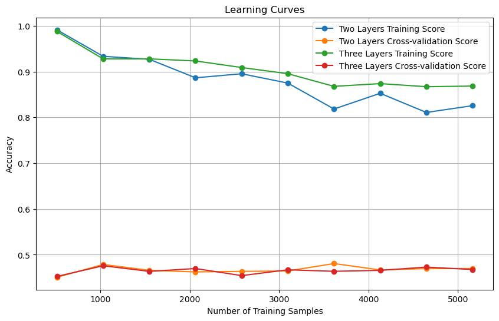

```python
# Define the sizes of the training set to be used for the learning curve
train_sizes = np.linspace(0.1, 1.0, 10)

# Generate learning curves for the two-layer neural network
train_sizes_2_layers, train_scores_2_layers, test_scores_2_layers = learning_curve(mlp_2_layers, X_train, y_train, train_sizes=train_sizes, cv=5)
train_scores_mean_2_layers = np.mean(train_scores_2_layers, axis=1)
test_scores_mean_2_layers = np.mean(test_scores_2_layers, axis=1)

# Generate learning curves for the three-layer neural network
train_sizes_3_layers, train_scores_3_layers, test_scores_3_layers = learning_curve(mlp_3_layers, X_train, y_train, train_sizes=train_sizes, cv=5)
train_scores_mean_3_layers = np.mean(train_scores_3_layers, axis=1)
test_scores_mean_3_layers = np.mean(test_scores_3_layers, axis=1)

# Plot the learning curves
plt.figure(figsize=(10, 6))
plt.plot(train_sizes_2_layers, train_scores_mean_2_layers, 'o-', label='Two Layers Training Score')
plt.plot(train_sizes_2_layers, test_scores_mean_2_layers, 'o-', label='Two Layers Cross-validation Score')
plt.plot(train_sizes_3_layers, train_scores_mean_3_layers, 'o-', label='Three Layers Training Score')
plt.plot(train_sizes_3_layers, test_scores_mean_3_layers, 'o-', label='Three Layers Cross-validation Score')
plt.xlabel('Number of Training Samples')
plt.ylabel('Accuracy')
plt.title('Learning Curves')
plt.legend()
plt.grid(True)
plt.show()
```

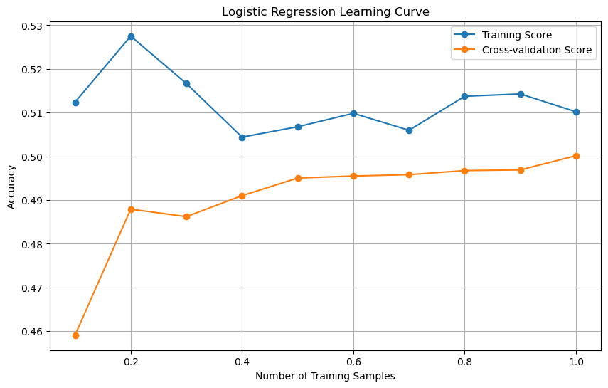

```python
plt.figure(figsize=(10, 6))
plt.plot(train_sizes, train_scores_mean, 'o-', label='Training Score')
plt.plot(train_sizes, test_scores_mean, 'o-', label='Cross-validation Score')
plt.xlabel('Number of Training Samples')
plt.ylabel('Accuracy')
plt.title('Logistic Regression Learning Curve')
plt.legend()
plt.grid(True)
plt.show()
```

**5.Compare the performance of the neural network models with logistic regression, discussing the strengths and weaknesses of each approach.**

**Logistic Regression:**

**Strengths:** Simplicity: Logistic regression is a simple and interpretable algorithm, making it easy to understand and implement. Efficiency: It's computationally efficient, especially for small datasets with linearly separable classes. Interpretability: Logistic regression provides coefficients for each feature, allowing interpretation of the impact of each feature on the prediction.

**Weaknesses:** Limited Complexity: Logistic regression assumes a linear relationship between features and the log-odds of the target variable. It might struggle to capture complex non-linear relationships in the data. Feature Engineering: Logistic regression heavily relies on feature engineering to represent non-linear relationships or interactions between features effectively. High Bias: Logistic regression might underfit complex datasets if the relationship between features and the target variable is non-linear.

**Neural Network Models:**

**Strengths:** Flexibility: Neural networks can capture complex non-linear relationships in the data due to their hierarchical structure and non-linear activation functions. Feature Learning: Neural networks can automatically learn useful features from raw data, reducing the need for extensive feature engineering. Scalability: Neural networks can scale to handle large datasets and high-dimensional feature spaces effectively.

**Weaknesses:** Complexity: Neural networks are complex models with many parameters, making them harder to interpret and prone to overfitting, especially on small datasets. Computational Intensity: Training neural networks can be computationally intensive, especially for deep architectures or large datasets, requiring substantial computational resources. Hyperparameter Tuning: Neural networks require careful tuning of hyperparameters such as learning rate, number of layers, neurons per layer, etc., which can be time-consuming and require expertise.

**Comparison:**

**Performance:** Neural networks generally outperform logistic regression on complex tasks with large datasets and non-linear relationships.

**Interpretability:** Logistic regression provides interpretable results with clear coefficients, making it suitable for scenarios where interpretability is crucial. Neural networks lack interpretability due to their complex nature.

**Computational Resources:** Logistic regression is computationally efficient and requires fewer computational resources compared to neural networks, making it suitable for low-resource environments or real-time applications.

**Data Size:** Logistic regression performs well on small to medium-sized datasets with linearly separable classes. Neural networks excel when dealing with large datasets or when complex patterns need to be learned.

In summary, the choice between logistic regression and neural networks depends on the specific characteristics of the dataset, the task at hand, computational resources, and the importance of interpretability. Logistic regression is suitable for simpler tasks with linear relationships, interpretability requirements, or limited computational resources. On the other hand, neural networks are preferred for complex tasks with non-linear relationships, large datasets, and when interpretability is not the primary concern.